# FIFA 19 Stats - Amazing Facts!

## - By Sakshat Rao

### Enjoy little interesting aspects of this FIFA 19 dataset through these wonderful visualizations...

#### This analysis is only for FIFA 19 and is not very suitable for real-world football. The reason being that there are many generated players and corresponding stats in this dataset...

## Table of Content:

1. Data
2. Country-Wise Analysis
3. Club Analysis
4. Player Analysis
5. Position Analysis

# Data

## Let us load and preprocess our data for further applications...

```
Data Sample :
```

|  | Unnamed: 0 | ID | Name | Age | Photo | Nationality | Flag | Overall | Potential | Club | ... | Composure | Marking | StandingTackle | SlidingTackle | GKDiving | GKHandling | GKKicking | GKPositioning | GKReflexes | Release Clause |
| --- | --- | --- | --- | --- | --- | --- | --- | --- | --- | --- | --- | --- | --- | --- | --- | --- | --- | --- | --- | --- | --- |
| 0 | 0 | 158023 | L. Messi | 31 | https://cdn.sofifa.org/players/4/19/158023.png | Argentina | https://cdn.sofifa.org/flags/52.png | 94 | 94 | FC Barcelona | ... | 96.0 | 33.0 | 28.0 | 26.0 | 6.0 | 11.0 | 15.0 | 14.0 | 8.0 | €226.5M |
| 1 | 1 | 20801 | Cristiano Ronaldo | 33 | https://cdn.sofifa.org/players/4/19/20801.png | Portugal | https://cdn.sofifa.org/flags/38.png | 94 | 94 | Juventus | ... | 95.0 | 28.0 | 31.0 | 23.0 | 7.0 | 11.0 | 15.0 | 14.0 | 11.0 | €127.1M |
| 2 | 2 | 190871 | Neymar Jr | 26 | https://cdn.sofifa.org/players/4/19/190871.png | Brazil | https://cdn.sofifa.org/flags/54.png | 92 | 93 | Paris Saint-Germain | ... | 94.0 | 27.0 | 24.0 | 33.0 | 9.0 | 9.0 | 15.0 | 15.0 | 11.0 | €228.1M |
| 3 | 3 | 193080 | De Gea | 27 | https://cdn.sofifa.org/players/4/19/193080.png | Spain | https://cdn.sofifa.org/flags/45.png | 91 | 93 | Manchester United | ... | 68.0 | 15.0 | 21.0 | 13.0 | 90.0 | 85.0 | 87.0 | 88.0 | 94.0 | €138.6M |
| 4 | 4 | 192985 | K. De Bruyne | 27 | https://cdn.sofifa.org/players/4/19/192985.png | Belgium | https://cdn.sofifa.org/flags/7.png | 91 | 92 | Manchester City | ... | 88.0 | 68.0 | 58.0 | 51.0 | 15.0 | 13.0 | 5.0 | 10.0 | 13.0 | €196.4M |

5 rows × 89 columns

```
Total no. of players in dataset -  18207
No. of columns containing missing values -  76
```

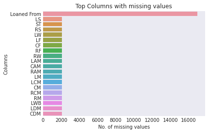

```
After preprocessing the data :


Player Data :

Total no. of players in dataset -  15926
No. of columns containing missing values -  0

Goalkeeper Data :

Total no. of players in dataset -  1992
No. of columns containing missing values -  0
```

Our analysis will therefore be based on around 18000 players, including around 2000 goalkeepers...

# Country-Wise Analysis

## Worldwide Distribution of Players

### Let us analyze the distribution of football players across the world in FIFA 19...

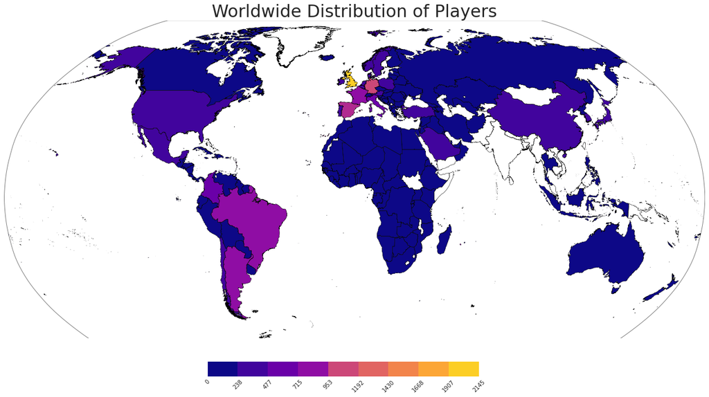

We see only one speck of yellow in the world map - the United Kingdom. The reason United Kingdom has been represented by so many players is that FIFA 19 has 4 English leagues and 1 Scottish league, which obviously will result in many English players being present in the FIFA 19 dataset.

The presence of football leagues in FIFA 19 of countries like China, Saudi Arabia, Japan, Colombia, Poland, Chile, Sweden, Norway and Turkey ensures decent representation of the mentioned countries as well.

## Average Overall Rating - Country-Wise

### We shall now move onto analyzing which countries have players with high average overall rating. We shall use 'Player Overall Rating' and 'Player Rating' interchangeably...

```
Average No. of Players Representing a Country =  112

Countries having representation lesser than 112 will not be considered for average overall rating...
```

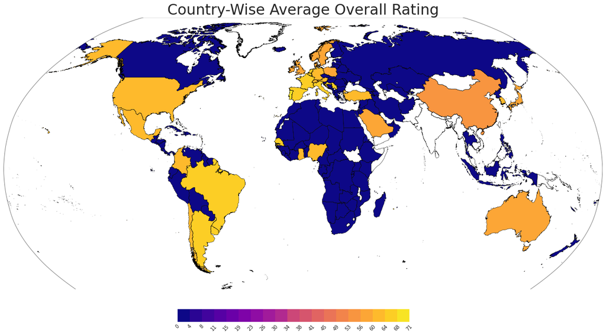

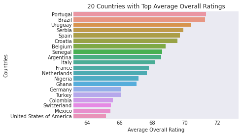

We see some really interesting observations here. Asian countries and Australia seem to have lesser average overall ratings. African countries, though poorly represented, have a good average overall rating with 3 African countries among the Top 20 countries.

Portugal and Brazil emerge as close winners. It is also interesting to observe that many of the top 20 countries do not have a very good representation (eg. Portugal, Uruguay etc.) while the United Kingdom, which has maximum representation, does not even appear in the top 20 countries. This might be happening because the lower-tier leagues in UK might be bringing the overall average rating down. On the other hand, most other countries have only their top football league in FIFA 19.

For example, if FIFA 19 would include Portugal's second tier league along with Liga NOS (the top-tier Portuguese league), then the average overall rating of Portugal would probably go down, while if FIFA 19 considered 'only' the Premier League in UK and not the lower-tier leagues, then the average overall rating of UK would be significantly higher.

## Country-Wise Average Player Value

### Let us check would there be any significant difference between average overall rating and average player value of countries...

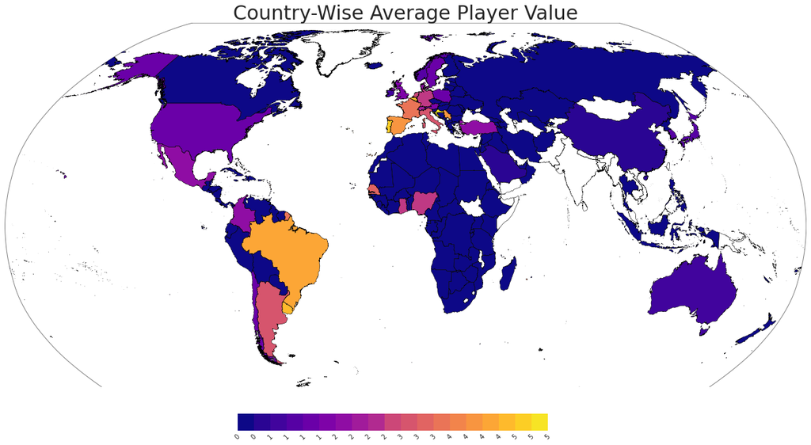

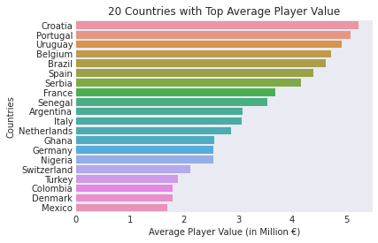

There doesn't seem to be much of a change between country-wise average overall rating and player value. Most of the top 20 countries with best average player values are also in the top 20 countries with best average overall rating. This represents justified value for money!

### Value For Money

We know try to figure out a pattern between player ratings and player value. We can, indeed, approximate the relation between ratings and values through an exponential curve. Using curve fitting, we find out the exact parameters and compare the available data and resulting curve...

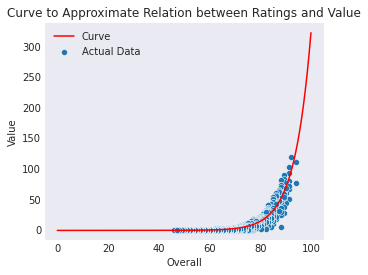

Therefore, using this curve as our 'Actual Player Value', we can find out by how much more or less money has a player been valued. This represents value for money; a player with value less than actual value represents good value for money, while a player with value more than actual value represents bad value for money...

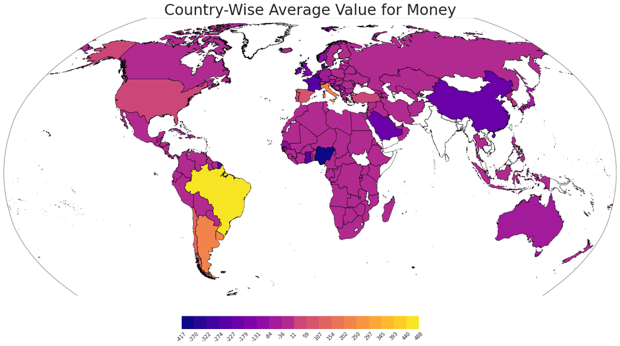

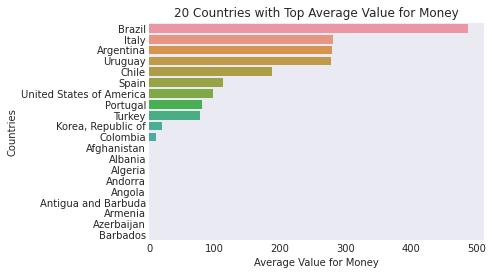

Brazillians steal the show with an incredibly high value for money. Again, the players in Brazillian clubs are made-up. However, the good thing about these players is that they have a high average player rating and terrific value for money. So you might not hesitate spending big bucks in FIFA 19 for a Brazillian player, for there is a high chance he'll be worth the money.

Also, there are only a handful of countries offering positive value for money, while the others offer negative value for money. So there is obviously severe over-pricing going on...

# Club Analysis

### Let us analyze average player age of the clubs...

```
No. of Clubs -  651
```

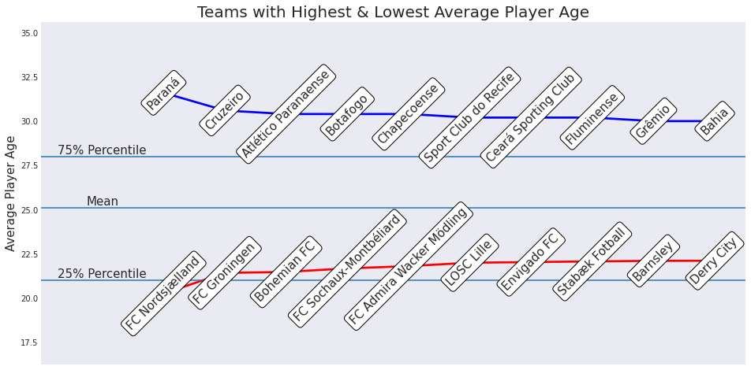

Actually, as mentioned, Brazillian clubs have made-up players in FIFA 19. So it just might be that made-up players innately have a higher average age. So if you are indeed interested in purchasing a player from a Brazillian club in FIFA 19, be aware that the player is made-up and that there is low chance of him being young.

### Let us now analyze average player rating, player potential and value for money of the clubs...

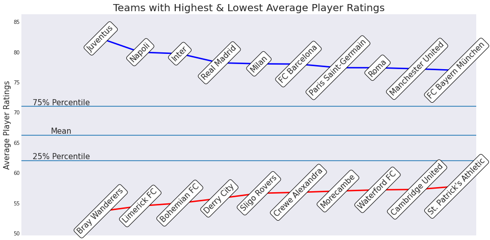

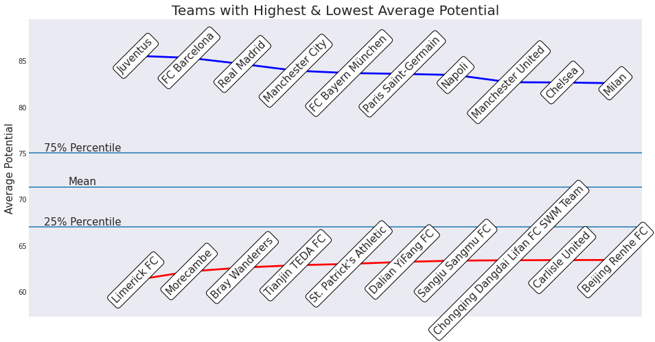

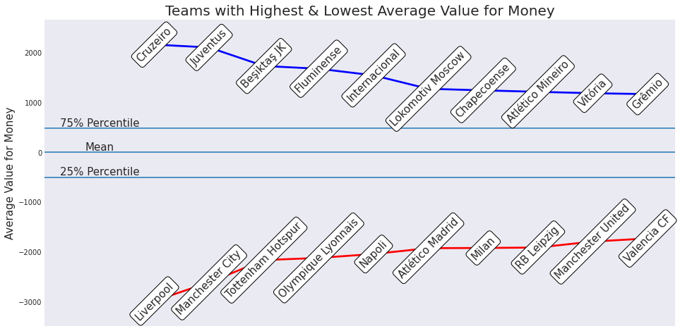

Juventus has a supreme average player rating over other teams. It is also surprising to see 5 Italian teams out of the top 10 teams with highest average ratings. Also all 10 teams with lowest average player rating are either from Ireland or UK, with as many as 7 out of them being Irish. Disappointing stats for Irish Football...

# Player Analysis

## Growth

### We have defined Growth as the difference between his Potential Rating & Overall Rating. Growth of a player might also be affected by his age, right? Let us check this dependency and also others...

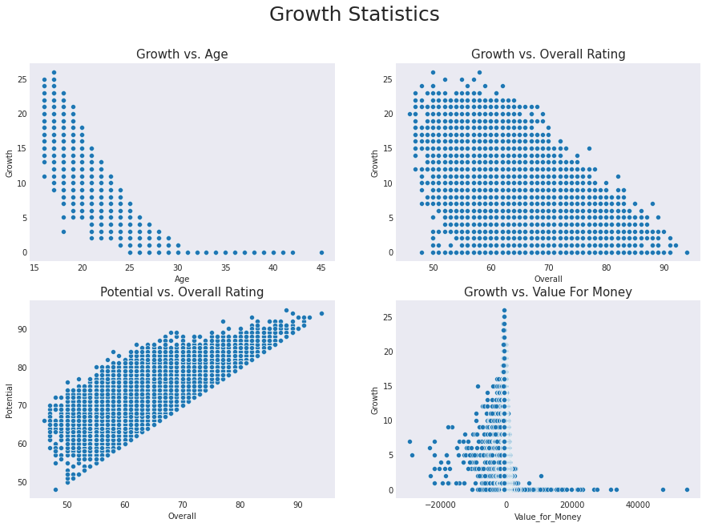

Important Observations :

- We see here that there is no player below 25 who is expected to have zero growth while no player above 30 is expected to have any kind of growth
- Players with lower overall rating can expect to have higher growth, though the trend is not definite and reliable
- No player has potential rating lower than overall rating, indicating no expected loss of quality for any player
- Players with high growth expectancy are having either moderate value for money or negative value for money. Thus, players with good growth are often valued close to or above their ideal value. But if the player does indeed fulfill his potential, it'll be a good investment in the long run

### Players with Highest Expected Growth

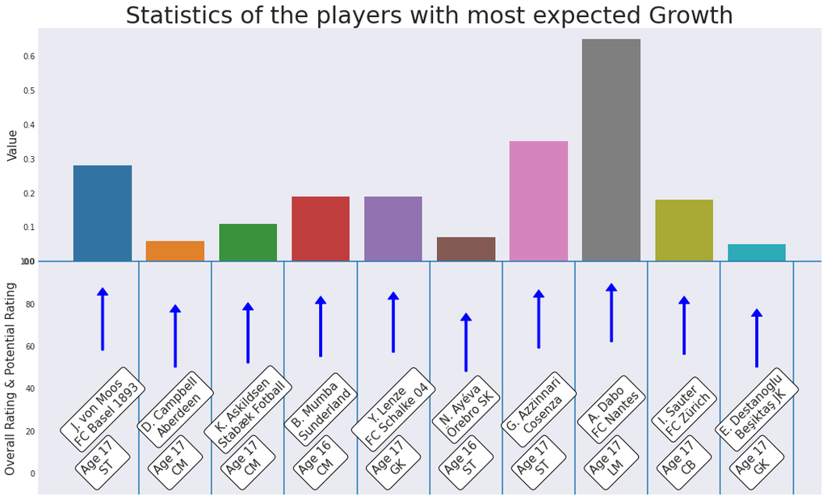

## Position Analysis

### To simplify our analysis, we'll categorize all footballing positions to 11 general positions -

- GK (GoalKeeper)
- CB, LB, RB (Defenders)
- CM, DM, LM, RM (Midfielders)
- CF, LF, RF (Forwards)

### Position Stats

```
Preferred Foot Count:

Right -  13748
Left -  4159

Natural Right-Footed to Left-Footed Ratio :
R:L = 13748:4159 = 3.31
```

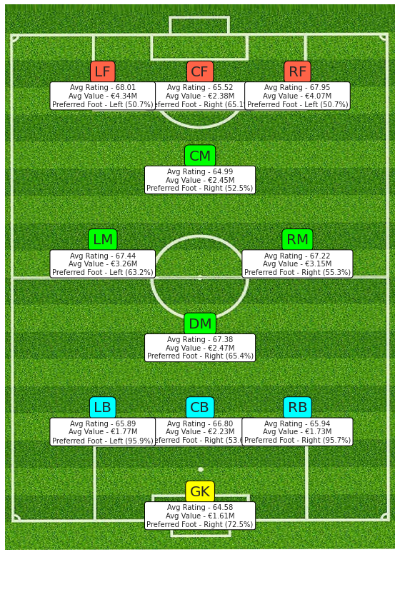

We notice some nice observations. Firstly, looking at average rating, we realize how relatively poor goalkeeper ratings really are. Also, it is a bit surprising to see a huge rating gap between Central Forwards and Side Forwards.

For average value, Side Forwards are much more expensive than others. On the other hand, defenders and goalkeepers are much cheaper.

It is interesting to look at the feet preference of different positions. The only positions where feet preference is one-sided are the side-back positions. This might be to effectively deliver those crosses. Side Midfielders and specially Side Forwards do not have that one-sided feet preference, indicating lot of flexibility in these positions. It is also a bit surprising to see almost 72% goalkeepers being right-footed, though it is a position where use of both feet are equally important.

## Best 'Non-Goalkeeper' Goalkeeper

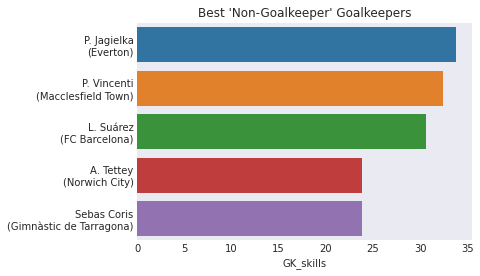

Suarez is the third best non-GK goalkeeper! I'm sure Ghanians wouldn't be as surprised as me...